# Preliminaries

```python
import tcrgp
import pickle
import ast
import csv
import numpy as np
from matplotlib import pyplot as plt
plt.style.use('ggplot')
```

## Create dictionary of V-genes and CDRs

- dictionary contains all possible V-gene - allele combinations and
- the corresponding cdr1, cdr2 & cdr2.5 sequences

```python
cdrs = tcrgp.create_cdr_dict(alignment='imgt',species=['human'])
```

## Get control data

```python
control_file = 'data/human_pairseqs_v1_parsed_seqs_probs_mq20_clones_random_nbrdists.tsv'
store_fields=['va_reps','vb_reps','cdr3a','cdr3b']
controls=[]
with open(control_file, newline='') as tsvfile:
    reader = csv.DictReader(tsvfile,delimiter='\t')
    for row in reader:
        entry = [row[s] for s in store_fields]
        cA = cdrs['human']['A'][entry[0].split(';')[0]]
        cB = cdrs['human']['B'][entry[1].split(';')[0]]
        if '*' not in ''.join(cB)+''.join(cA)+entry[2]+entry[3]:
            controls.append(entry)

n_controls = len(controls)
```

## Get feature representation

We have used the principal components of a modified BLOSUM62 matrix as features. We obtained best results when using all d=21 components, but is possible to use a smaller d. It is also possible to use also other features, as long as they have the correct form.

```python
subsmat = tcrgp.subsmatFromAA2('HENS920102')
pc_blo = tcrgp.get_pcs(subsmat,d=21)
```

# Melan-a

## Read data

```python
datafile = 'data/melana.txt'
subjects, cdr3s = np.loadtxt(datafile,dtype=str,delimiter='\t',comments=None,unpack=True,skiprows=1,usecols=[0,5],encoding='latin1')
```

```python
n_e = len(subjects)
n_s = len(np.unique(subjects))
print(str(n_s)+' subjects, '+str(n_e)+' samples')
```

```
6 subjects, 356 samples
```

## Write data files for training

Create a separate data file for each epitope. Add epitope-specific TCRs and control TCRs.

```python
epi='melan-a'
with open('training_data/melana.csv','w') as csvfile:
    writer = csv.writer(csvfile, delimiter=',')
    writer.writerow(['epitope','subject','va','vb','cdr3a','cdr3b'])
    for subject, cdr in zip(subjects,cdr3s):
        writer.writerow([epi,subject,'','','',cdr])
    for i in np.random.choice(range(n_controls),n_e).astype(int):
            writer.writerow(['none','control','',controls[i][1],'',controls[i][3]])
```

## Leave-one-subject-out cross-validations

Leave-one-subject-out (loso) cross-validations can be used to evaluate the performance of the model.

### Train model with human TCR$\beta$s recognizing melan-a

- use only CDR3$\beta$
- use max. 5000 iterations and learning rate 0.005

```
human melan-a: 6 subjects, 356 samples
```

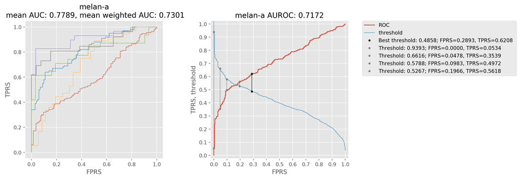

```python
_,_,_,_ = tcrgp.loso('training_data/melana.csv','human',epi,pc_blo,cdr_types=[[],['cdr3']],
                     m_iters=5000,lr=0.005,nZ=0,mbs=0,va=None,vb='vb',cdr3a=None,cdr3b='cdr3b',epis='epitope',subs='subject')
```

## Training, saving and loading models

### Train the model with desired options

- auc is the AUC score for the training data
- params contains all necessary informatio for re-building the model
- Train with 5000 iterations and learning rate 0.005
- Set the maximum cdr3B length to 23

```python
auc, params = tcrgp.train_classifier('training_data/melana.csv','human',epi,pc_blo,
                                     cdr_types=[[],['cdr3']],m_iters=5000,lr=0.005,nZ=0,mbs=0,l3_max=23,
                                     va=None,vb=None,cdr3a=None,cdr3b='cdr3b',epis='epitope')
```

### Save the model parameters

```python
with open('models/models_melana_cdr3b','wb') as f:
    pickle.dump(params,f)
```

### Load the model parameters

```python
with open('models/models_melana_cdr3b','rb') as f:
    params = pickle.load(f)
```

### Do predictions for new TCRs

```python
files = ['non_naive_1.csv','non_naive_2.csv','non_naive_3.csv']
seqs_melana = []
preds_melana= []

for file in files:
    seqs, preds = tcrgp.predict('data/'+file,params,[[],['cdr3']],cdr3b='cdr3aa',va=None,vb=None,cdr3a=None)
    seqs_melana.append(seqs)
    preds_melana.append(preds)
```

```
Maximum length for test CDR3s is 27, but the maximum length for the trained model is 23.
You need to train a new model with longer sequences to get predictions for all sequences.
Maximum length for test CDR3s is 27, but the maximum length for the trained model is 23.
You need to train a new model with longer sequences to get predictions for all sequences.
Maximum length for test CDR3s is 27, but the maximum length for the trained model is 23.
You need to train a new model with longer sequences to get predictions for all sequences.
```

# Meloe1

## Read data

```python
datafile = 'data/meloe1.txt'
subjects, cdr3s = np.loadtxt(datafile,dtype=str,delimiter='\t',comments=None,unpack=True,skiprows=1,usecols=[0,5],encoding='latin1')
```

```python
n_e = len(subjects)
n_s = len(np.unique(subjects))
print(str(n_s)+' subjects, '+str(n_e)+' samples')
```

```
4 subjects, 156 samples
```

### Check that all CDR3s have only valid characters

remove invalid from training set

```python
I = np.ones((n_e,),dtype=bool)
for i in range(n_e):
    if not all([letter in tcrgp.alphabet for letter in cdr3s[i]]):
        print(str(i)+' '+cdr3s[i])
        I[i] = False

subjects=subjects[I]
cdr3s=cdr3s[I]

n_e = len(subjects)
n_s = len(np.unique(subjects))
print(str(n_s)+' subjects, '+str(n_e)+' samples')
```

```
68 CHLRFLPLP?GWGRGTSREETFLYHGVTLWGLAGAYNEQFF
4 subjects, 155 samples
```

## Write data files for training

Create a separate data file for each epitope. Add epitope-specific TCRs and control TCRs.

```python
epi='meloe-1'
with open('training_data/meloe1.csv','w') as csvfile:
    writer = csv.writer(csvfile, delimiter=',')
    writer.writerow(['epitope','subject','va','vb','cdr3a','cdr3b'])
    for subject, cdr in zip(subjects,cdr3s):
        writer.writerow([epi,subject,'','','',cdr])
    for i in np.random.choice(range(n_controls),n_e).astype(int):
            writer.writerow(['none','control','',controls[i][1],'',controls[i][3]])
```

## Leave-one-subject-out cross-validations

Leave-one-subject-out (loso) cross-validations can be used to evaluate the performance of the model.

### Train model with human TCR$\beta$s recognizing meloe-1

- use only CDR3$\beta$
- use max. 5000 iterations and learning rate 0.005

```
human meloe-1: 4 subjects, 155 samples
```

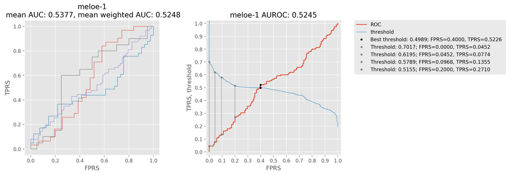

```python
_,_,_,_ = tcrgp.loso('training_data/meloe1.csv','human',epi,pc_blo,cdr_types=[[],['cdr3']],
                     m_iters=5000,lr=0.005,nZ=0,mbs=0,va=None,vb='vb',cdr3a=None,cdr3b='cdr3b',epis='epitope',subs='subject',min_subjects=4)
```

This does not seem too great. Let's try again after removing some strange TCRs

```python
subjects, cdr3s = np.loadtxt(datafile,dtype=str,delimiter='\t',comments=None,unpack=True,skiprows=1,usecols=[0,5],encoding='latin1')
n_e = len(subjects)
n_s = len(np.unique(subjects))
print(str(n_s)+' subjects, '+str(n_e)+' samples')

I = np.ones((n_e,),dtype=bool)
for i in range(n_e):
    if (cdr3s[i][0] is not 'C') or (cdr3s[i][-1] not in 'FW') or (len(cdr3s[i])>23) or not all([letter in tcrgp.alphabet for letter in cdr3s[i]]):
        print(str(i)+' '+cdr3s[i])
        I[i] = False

subjects=subjects[I]
cdr3s=cdr3s[I]

n_e = len(subjects)
n_s = len(np.unique(subjects))
print('\n' + str(n_s) + ' subjects, ' + str(n_e) + ' samples')
```

```
4 subjects, 156 samples
68 CHLRFLPLP?GWGRGTSREETFLYHGVTLWGLAGAYNEQFF
94 CDTFVSQTPKYLVTQMGNDKSIKCEQNLGHDTMYWYKQDSKKFLKIMFSYNNKELIINETVPNRFSPKSPDKAHLNLHINSLELGDSAVYFCASSQEGSDRGRLHEQFF
109 VSTLTIQRTQQEDSAVYLCASSRPRARHNEQFF

4 subjects, 153 samples
```

## Write data files for training

Create a separate data file for each epitope. Add epitope-specific TCRs and control TCRs.

```python
epi='meloe-1'
with open('training_data/meloe1_fixed.csv','w') as csvfile:
    writer = csv.writer(csvfile, delimiter=',')
    writer.writerow(['epitope','subject','va','vb','cdr3a','cdr3b'])
    for subject, cdr in zip(subjects,cdr3s):
        writer.writerow([epi,subject,'','','',cdr])
    for i in np.random.choice(range(n_controls),n_e).astype(int):
            writer.writerow(['none','control','',controls[i][1],'',controls[i][3]])
```

## Leave-one-subject-out cross-validations

Leave-one-subject-out (loso) cross-validations can be used to evaluate the performance of the model.

```
human meloe-1: 4 subjects, 153 samples
```

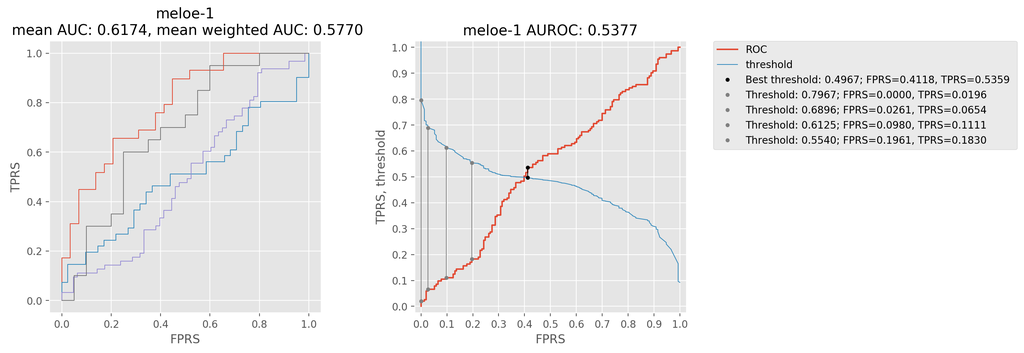

```python
_,_,_,_ = tcrgp.loso('training_data/meloe1_fixed.csv','human',epi,pc_blo,cdr_types=[[],['cdr3']],
                     m_iters=5000,lr=0.005,nZ=0,mbs=0,va=None,vb='vb',cdr3a=None,cdr3b='cdr3b',epis='epitope',subs='subject',min_subjects=4)
```

## Training, saving and loading models

### Train the model with desired options

- auc is the AUC score for the training data
- params contains all necessary informatio for re-building the model
- Train with 5000 iterations and learning rate 0.005
- Set the maximum cdr3B length to 23

```python
auc, params = tcrgp.train_classifier('training_data/meloe1_fixed.csv','human',epi,pc_blo,
                                     cdr_types=[[],['cdr3']],m_iters=5000,lr=0.005,nZ=0,mbs=0,l3_max=23,
                                     va=None,vb=None,cdr3a=None,cdr3b='cdr3b',epis='epitope')
```

### Save the model parameters

```python
with open('models/models_meloe1_cdr3b','wb') as f:
    pickle.dump(params,f)
```

### Load the model parameters

```python
with open('models/models_meloe1_cdr3b','rb') as f:
    params = pickle.load(f)
```

### Do predictions for new TCRs

```python
files = ['non_naive_1.csv','non_naive_2.csv','non_naive_3.csv']
seqs_meloe1 = []
preds_meloe1= []

for file in files:
    seqs, preds = tcrgp.predict('data/'+file,params,[[],['cdr3']],cdr3b='cdr3aa',va=None,vb=None,cdr3a=None)
    seqs_meloe1.append(seqs)
    preds_meloe1.append(preds)
```

```
Maximum length for test CDR3s is 27, but the maximum length for the trained model is 23.
You need to train a new model with longer sequences to get predictions for all sequences.
Maximum length for test CDR3s is 27, but the maximum length for the trained model is 23.
You need to train a new model with longer sequences to get predictions for all sequences.
Maximum length for test CDR3s is 27, but the maximum length for the trained model is 23.
You need to train a new model with longer sequences to get predictions for all sequences.
```

## Read original id:s

```python
identifiers=[]
for file in files:
    ids=np.loadtxt('data/'+file,dtype=str,delimiter=',',comments=None,skiprows=1,usecols=[11])
    identifiers.append(ids)
```

# Write all results to file

```python
with open('results/results_non_naive.csv', 'w', newline='') as csvfile:
    writer = csv.writer(csvfile, delimiter=',')
    writer.writerow(['id','CDR3B','melan-a','meloe-1'])
    for ids,seqs,ps_melana,ps_meloe1 in zip(identifiers,seqs_melana,preds_melana,preds_meloe1):
        for i, seq,p_melana,p_meloe1 in zip(ids,seqs[0],ps_melana,ps_meloe1):
            writer.writerow([i, seq,'{:.4f}'.format(p_melana[0]),'{:.4f}'.format(p_meloe1[0])])
```